# Red Wine Quality Analysis

### Which chemical properties influence the quality of red wines?

By Linjing Yang

# Introduction

The tidy data set contains 1,599 red wines [^1] with 11 variables on the chemical properties of the wine. At least 3 wine experts rated the quality of each wine, providing a rating between 0 (very bad) and 10 (very excellent).

- 1599 records
- 11 chemical properties
- quality rating: 0 - 10

## Variables

### Input variables (based on physicochemical tests):

1. fixed acidity (tartaric acid - g / dm^3)
2. volatile acidity (acetic acid - g / dm^3)
3. citric acid (g / dm^3)
4. residual sugar (g / dm^3)
5. chlorides (sodium chloride - g / dm^3
6. free sulfur dioxide (mg / dm^3)
7. total sulfur dioxide (mg / dm^3)
8. density (g / cm^3)
9. pH
10. sulphates (potassium sulphate - g / dm3)
11. alcohol (% by volume)

### Output variable (based on sensory data):

12. quality (score between 0 and 10)

# Exploration of Data

| fixed.acidity | volatile.acidity | citric.acid | residual.sugar | chlorides | free.sulfur.dioxide | total.sulfur.dioxide | density | pH | sulphates | alcohol | quality |
| --- | --- | --- | --- | --- | --- | --- | --- | --- | --- | --- | --- |
| 7.4 | 0.70 | 0.00 | 1.9 | 0.076 | 11 | 34 | 0.9978 | 3.51 | 0.56 | 9.4 | 5 |
| 7.8 | 0.88 | 0.00 | 2.6 | 0.098 | 25 | 67 | 0.9968 | 3.20 | 0.68 | 9.8 | 5 |
| 7.8 | 0.76 | 0.04 | 2.3 | 0.092 | 15 | 54 | 0.9970 | 3.26 | 0.65 | 9.8 | 5 |
| 11.2 | 0.28 | 0.56 | 1.9 | 0.075 | 17 | 60 | 0.9980 | 3.16 | 0.58 | 9.8 | 6 |
| 7.4 | 0.70 | 0.00 | 1.9 | 0.076 | 11 | 34 | 0.9978 | 3.51 | 0.56 | 9.4 | 5 |
| 7.4 | 0.66 | 0.00 | 1.8 | 0.075 | 13 | 40 | 0.9978 | 3.51 | 0.56 | 9.4 | 5 |

## Univariate

The main purpose of this report is to discover the chemicals that could predict the quality of wines. Besides, from the name of the 12 variables, we may find that some of them might be correlated with others (e.g. Acid and PH).

Thus, the analysis would include the calculation of correlation and linear regression, both of which may requires a normal distribution of variables.

In the univariate plots and analysis, it is focused on exploring the distribution of variables.

### Histogram of All the Variables

There are 11 continuous variables and one ordinal variable. Most of them are skewed to right.

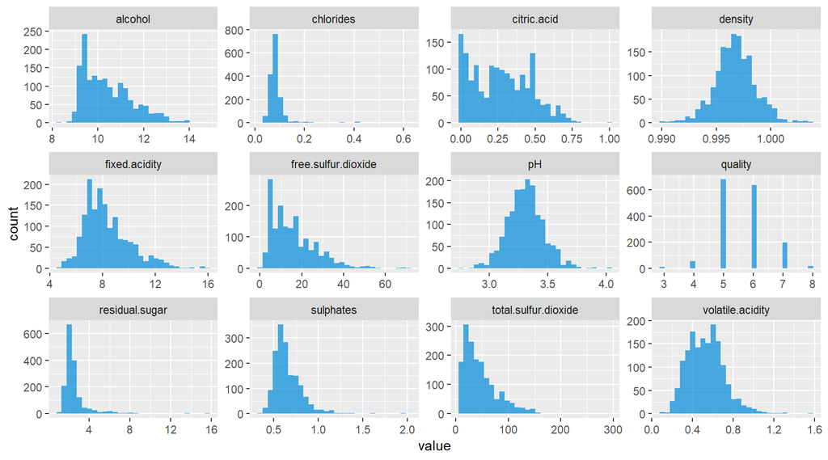

### Quality (Rating 0 - 10)

Quality is the only ordinal variable in the data set. Though the range of it is 0-10, there is no wine ranked as 0-2 or 9-10. Most of the wines were scored as 5-6.

```
##    Min. 1st Qu.  Median    Mean 3rd Qu.    Max.
##   3.000   5.000   6.000   5.636   6.000   8.000
```

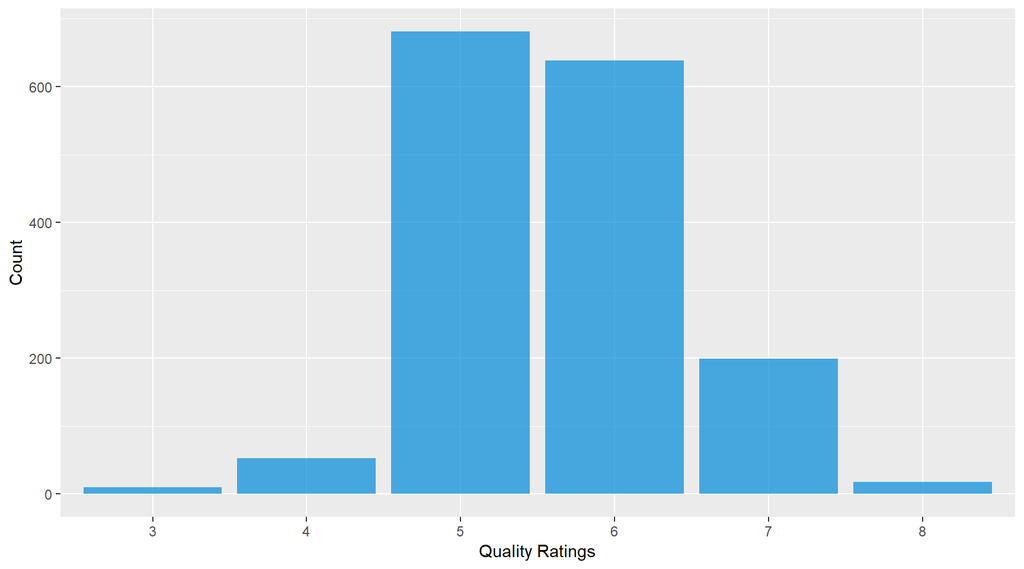

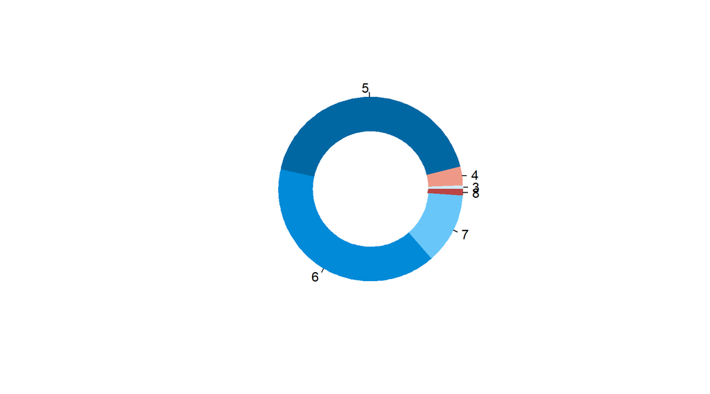

### Chemicals

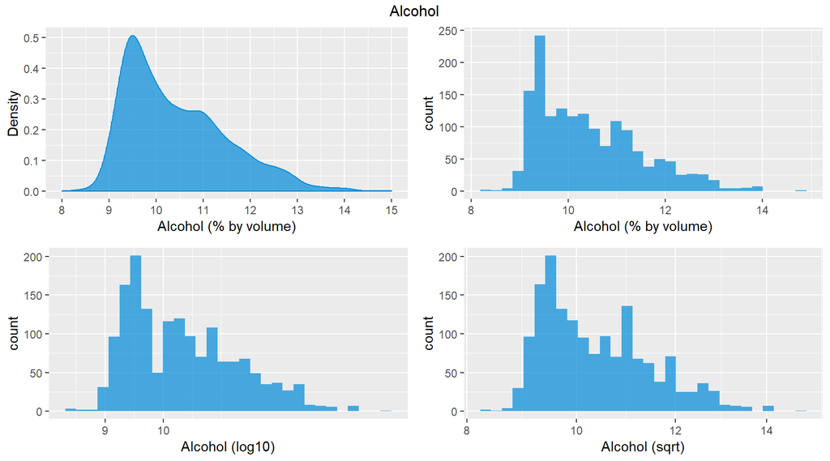

```
## Alcohol
##
##
##    Min. 1st Qu.  Median    Mean 3rd Qu.    Max.
##    8.40    9.50   10.20   10.42   11.10   14.90
##
##
## The percentage of alcohol is between 8.40 and 14.90.
##
## It is rightly skewed, and most wines have 9% -12% alcohol,
## with the median of 10.20% and mean of 10.42%.
##
## I tried to normalise it by log10 or sqrt, but the distribution of them did not seem better.
```

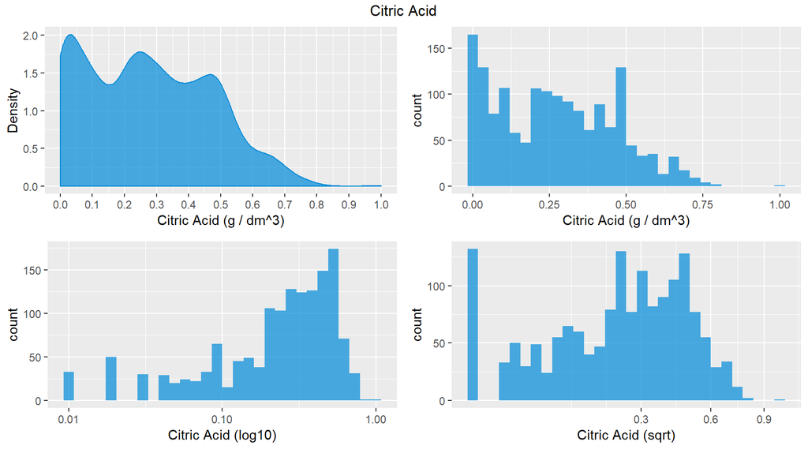

```
## Citric Acid
##
##
##    Min. 1st Qu.  Median    Mean 3rd Qu.    Max.
##   0.000   0.090   0.260   0.271   0.420   1.000
##
##
## Citric Acid ranges from 0 to 1 g / dm^3.
##
## There are 3 peaks in the distribution of Citric Acid with a long tail to the right.
##
## The 1st peak is between 0.0-0.1, with the 2nd in 0.2-0.3 and 3rd in 0.4-0.5.
##
## There is a sharp decrease betwenn 0.5 and 0.6.
##
## Most of wines have less than 0.5 g / dm^3 Citric Acid.
##
## Again, the log10 and sqrt method could not normalise it.
```

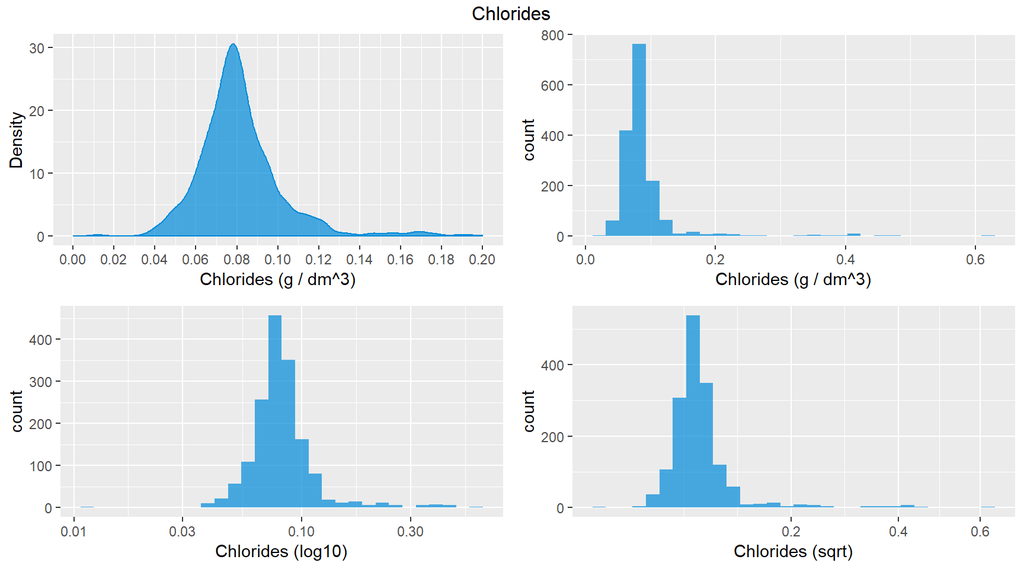

```
## Chlorides
##
##
##    Min. 1st Qu.  Median    Mean 3rd Qu.    Max.
## 0.01200 0.07000 0.07900 0.08747 0.09000 0.61100
##
##
## The distribution of Chlorides is almost normal.
##
## Most wines have 0.04 - 0.12 g / dm^3 Chlorides, with the mean of 0.087.
##
## Though it ranges from 0.012 to 0.611,
## there are very few wines with the Chlorides of 0.012 - 0.04 or 0.12 - 0.611.
```

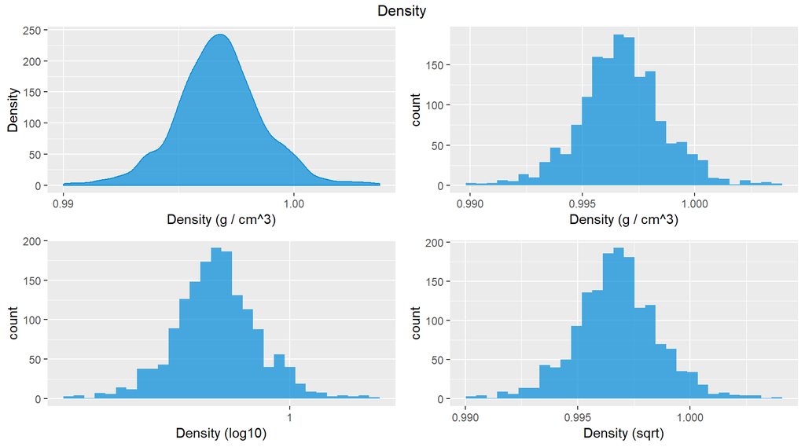

```
## Density
##
##
##    Min. 1st Qu.  Median    Mean 3rd Qu.    Max.
##  0.9901  0.9956  0.9968  0.9967  0.9978  1.0037
##
##
## Density is almost normaly distributed.
##
## Most wines have the density of 0.9956 - 0.9978 g / dm^3,
## with the mean of 0.9967.
```

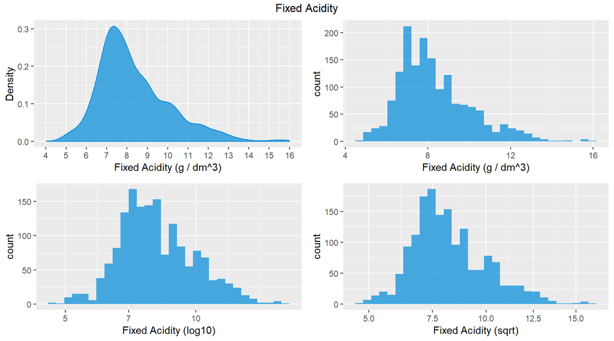

```
## Fixed Acidity
##
##
##    Min. 1st Qu.  Median    Mean 3rd Qu.    Max.
##    4.60    7.10    7.90    8.32    9.20   15.90
##
##
## Fixed Acidity is a bit rightly skewed.
##
## Though it ranges from 4.60 to 15.90 g / dm^3,
## most of wines have the fixed acidity of 5 -13,
## with the median of 7.90.
##
## The mode is between 7 -8.
##
## Compared with sqrt, Log10 seems to be a better method to nomalise it.
```

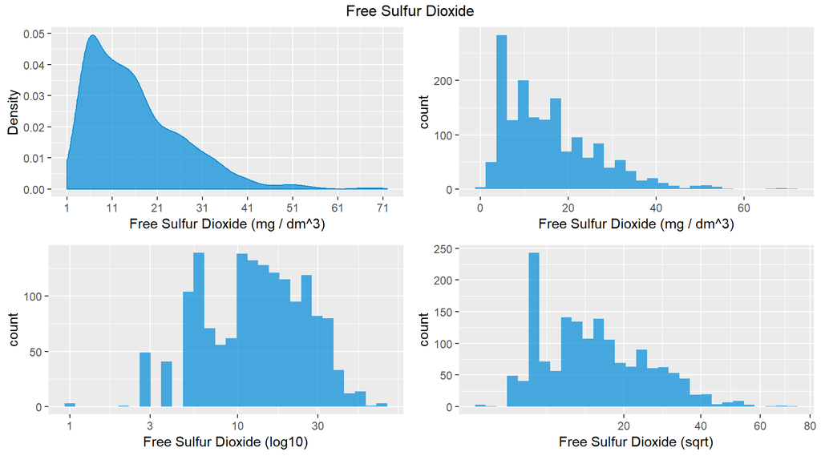

```
## Free Sulfur Dioxide
##
##
##    Min. 1st Qu.  Median    Mean 3rd Qu.    Max.
##    1.00    7.00   14.00   15.87   21.00   72.00
##
##
## Free Sulfur Dioxide is right skewed with a long tail to the right.
##
## The peak of the distribution is between 6 - 11 mg/dm^3.
##
## Though it ranges from 1 - 72,
## most wines have the Free Sulfur Dioxide less than 41.
##
## Sqrt could make it like a normal distribution than log10.
```

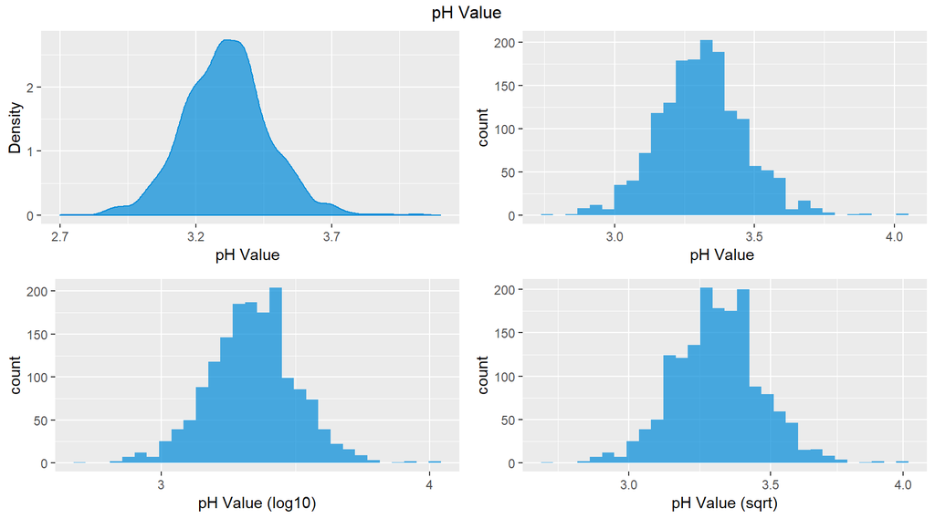

```
## pH Value
##
##
##    Min. 1st Qu.  Median    Mean 3rd Qu.    Max.
##   2.740   3.210   3.310   3.311   3.400   4.010
##
##
## PH values look like normally distributed.
##
## It mainly ranges from 3.0 to 3.6, with the mean of 3.311.
```

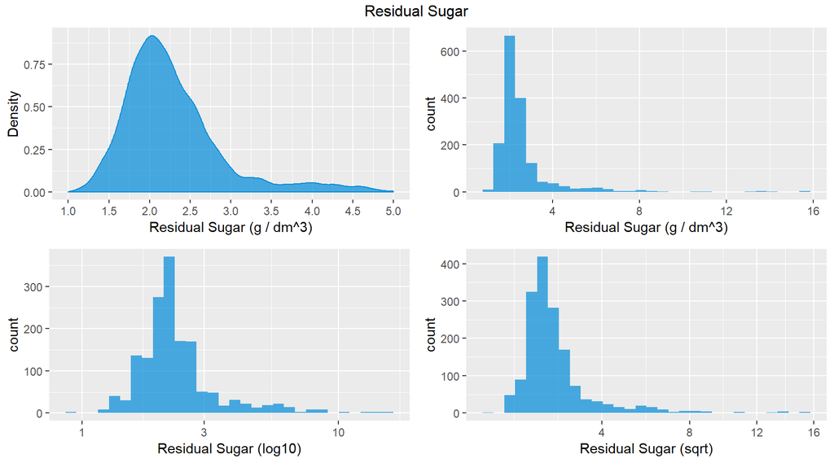

[output not shown]

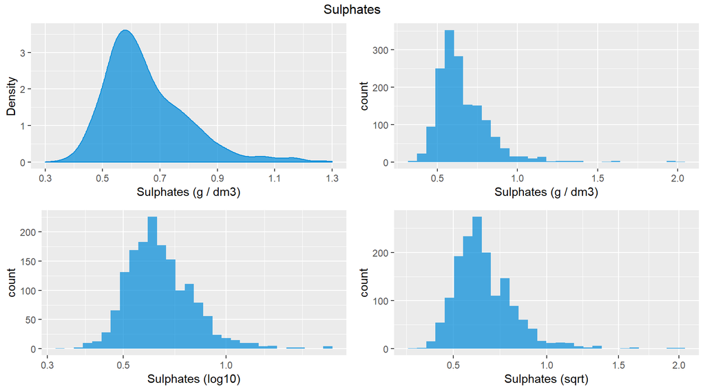

```
## Sulphates
##
##
##    Min. 1st Qu.  Median    Mean 3rd Qu.    Max.
##  0.3300  0.5500  0.6200  0.6581  0.7300  2.0000
##
##
## Sulphates is right skewed.
##
## Though it ranges from 0.33 to 2.00 g/dm^3,
## the Sulphates of most wines are less than 1.0.
##
## From the histogram, it could be seen that
## there is another small peak between these two (near 0.5).
##
## Log10 method is more suitable to normalise the Sulphates
```

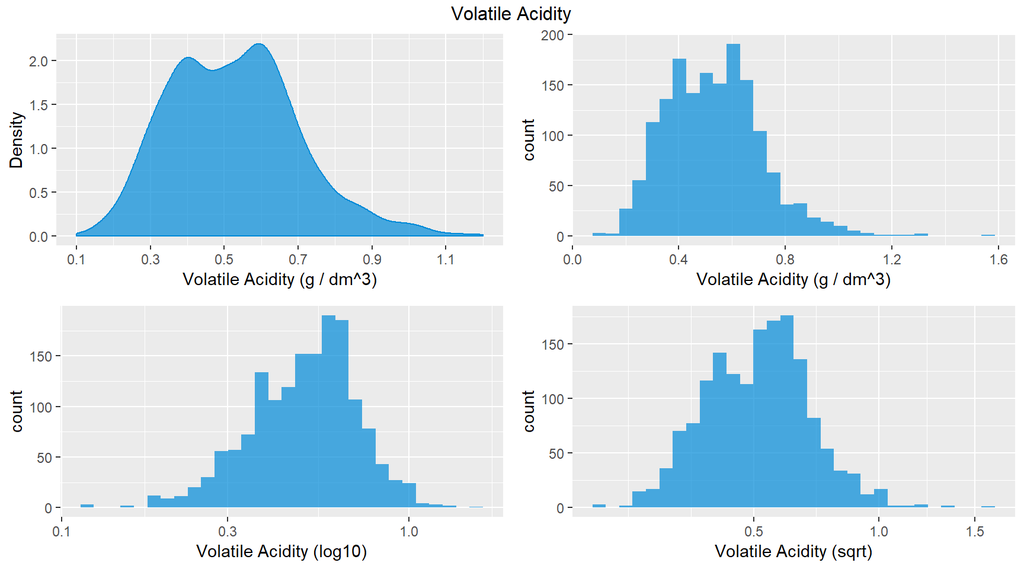

```
## Volatile Acidity
##
##
##    Min. 1st Qu.  Median    Mean 3rd Qu.    Max.
##  0.1200  0.3900  0.5200  0.5278  0.6400  1.5800
##
##
## Volatile is bimodal distributed,
## with the 1st peak around 0.4 g/dm^3 and the 2nd near 0.6.
##
## Most wines have the acidity between 0.3 to 0.7.
```

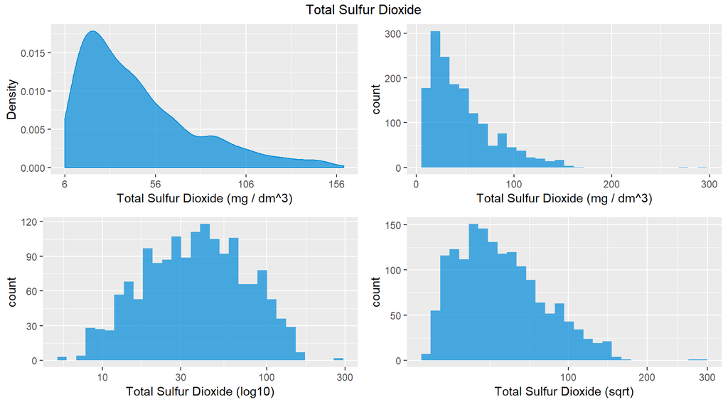

[output not shown]

## Bivariate - Quality vs Chemicals

### Plots: Quality vs Chemicals

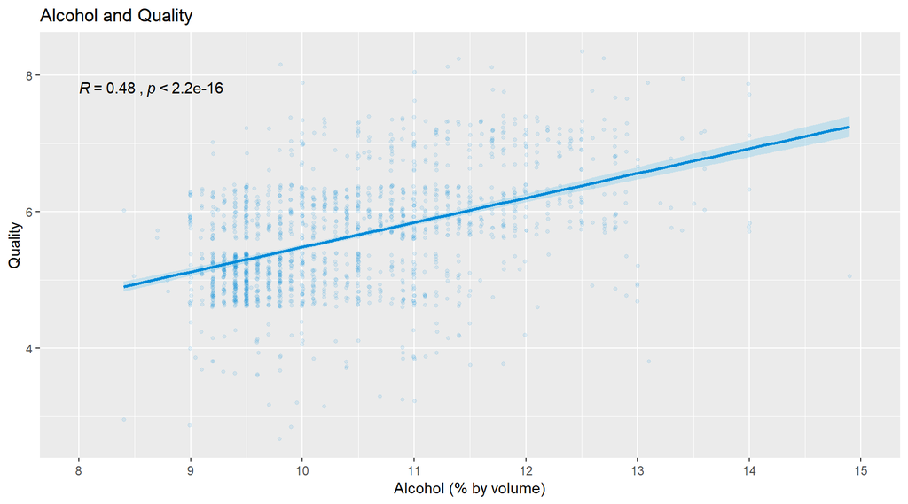

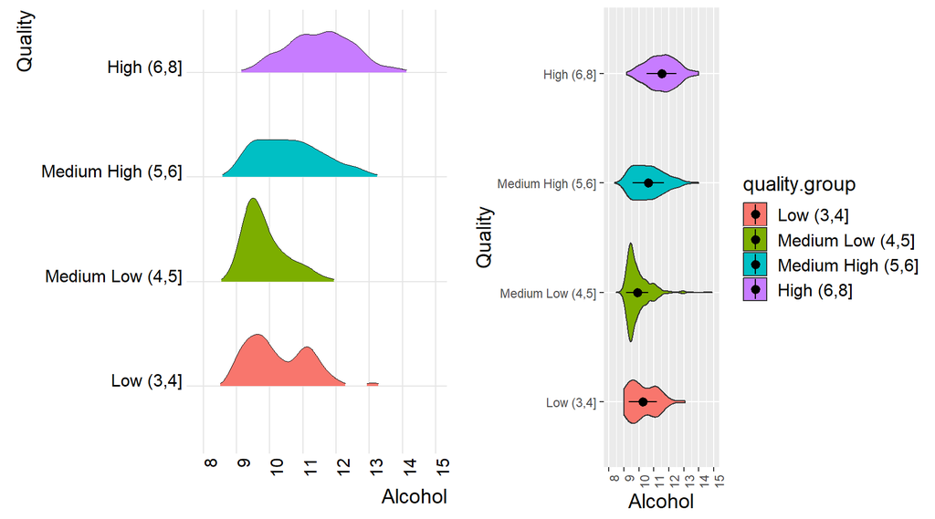

Alcohol and Quality

From scatter plot, it can be seen that when alcohol increases, the quality score rises.

From the ridgeline and violine plot, it could be found that when the quality score increases, the alcohol distribution moves to the right (alcohol increases), but the shapes are different to each other.

Thus, I guess even though they are positively correlated, the correlation might not be strong.

The spearman coefficient (0.48) shows that they are mild correlated, same as what we got from the plots.

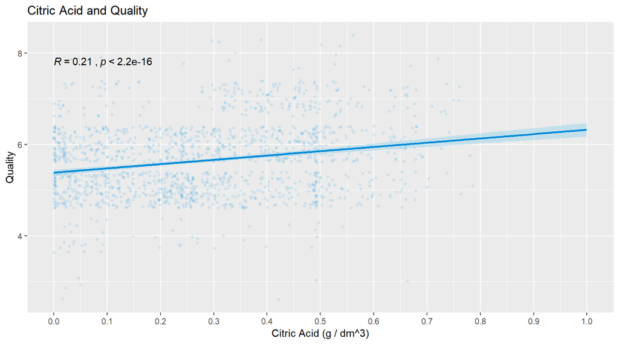

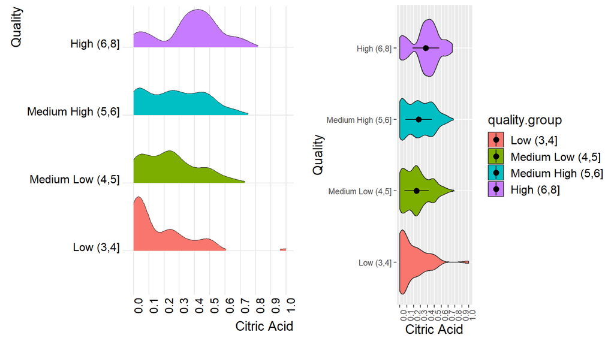

Citric Acid and Quality

Thus, I guess Citric Acid and Quality are not correlated.

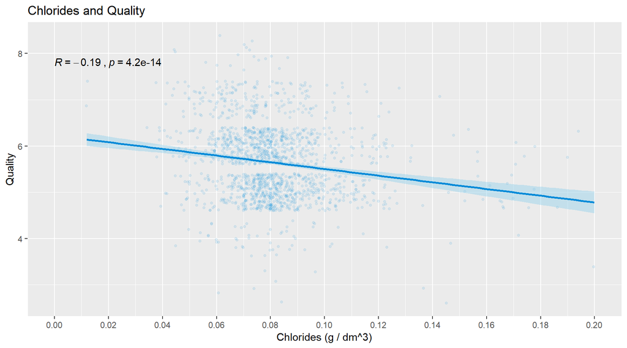

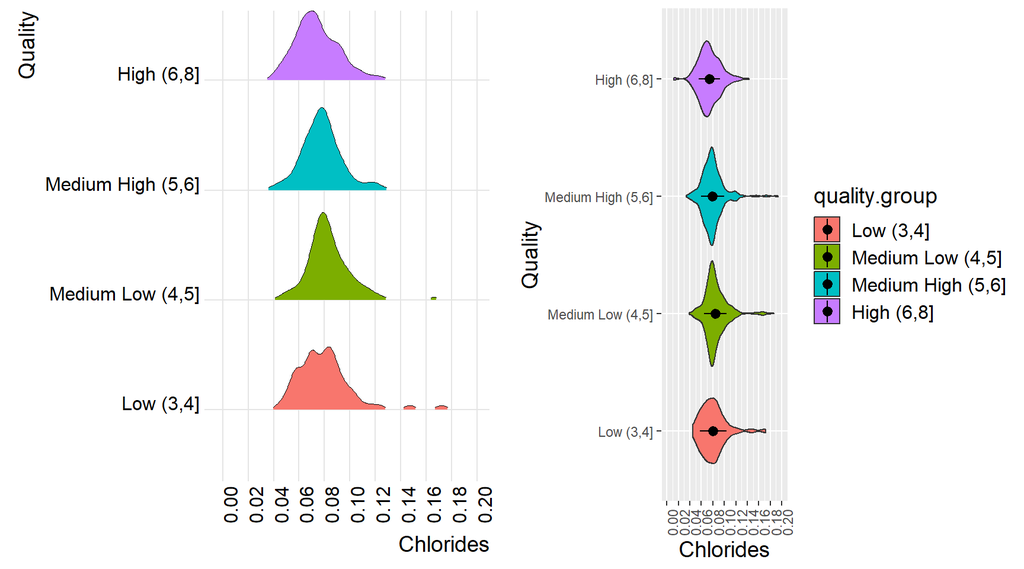

Chlorides and Quality

From scatter plot, it can be seen that the quality score does not have any changes, when the cchlorides increase.

In the ridgeline and violine plot, the x of the distributions just move to the left a bit, with the change of the quality groups. The shape of the 4 groups in the plots are very similar, especially the 2 groups in the middle, which represents most of the wines.

Thus, I guess chlorides and Quality are not correlated.

The spearman coefficient is -0.19 (not correlated)indicating a same result as what we got from the plots.

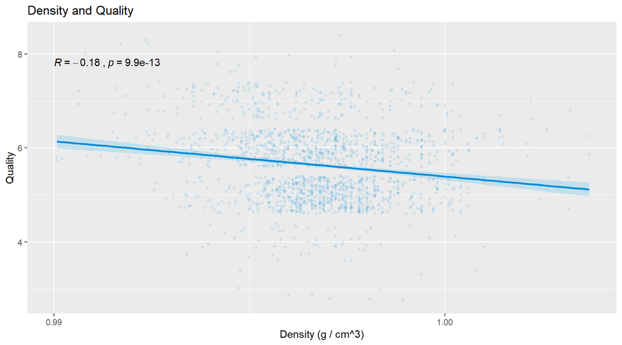

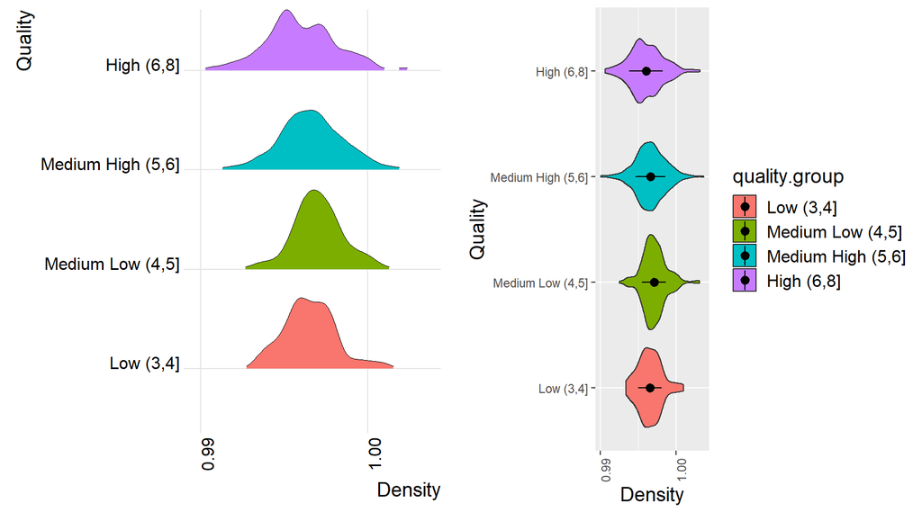

Density and Quality

From scatter plot, it can be seen that the quality score does not have any changes, when the density increase.

In the ridgeline and violine plot, the x of the distributions does not move, with the change of the quality groups. The shape of the 4 groups in the plots are very similar, especially the 2 groups in the middle, which represents most of the wines.

Thus, I guess density and Quality are not correlated.

The spearman coefficient is -0.18 (not correlated), indicating a same result as what we got from the plots.

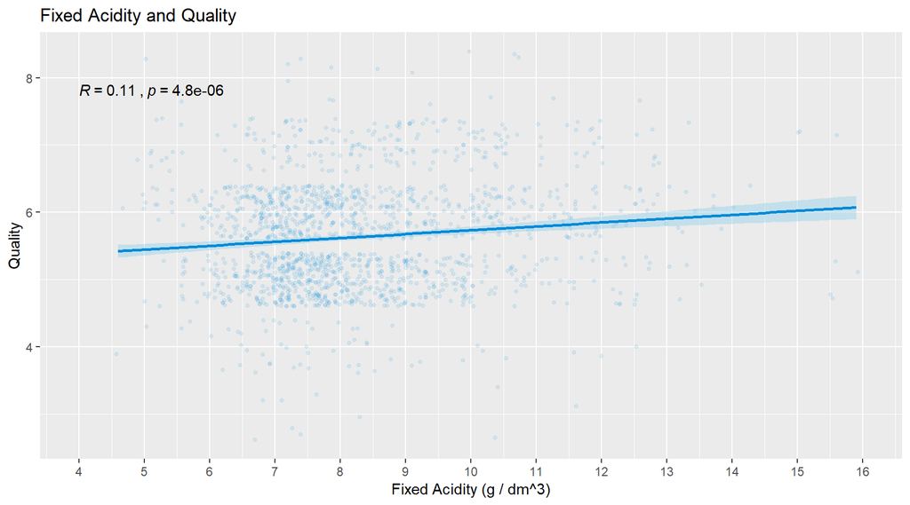

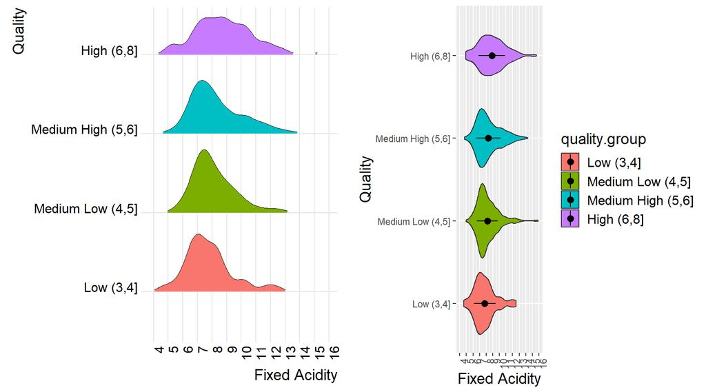

Fixed Acidity and Quality

From scatter plot, it can be seen that the quality score does not have any changes, when the fixed acidity increases.

In the ridgeline and violine plot, the x of the distributions does not move, with the change of the quality groups. The shape of the 2 groups in the middle are almost same.

Thus, I guess fixed acidity and Quality are not correlated.

The spearman coefficient is 0.11 (not correlated), indicating a same result as what we got from the plots.

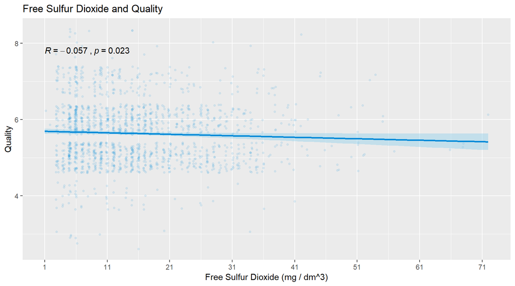

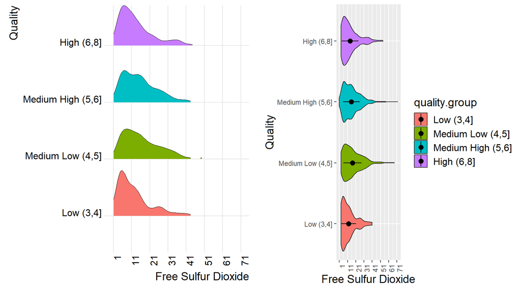

Free Sulfur Dioxide and Quality

From scatter plot, it can be seen that the quality score does not have any changes, when Free Sulfur Dioxide increase.

In the ridgeline and violine plot, the x of the distributions does not move, with the change of the quality groups. The shape of the 4 groups in the plots are very similar.

Thus, I guess Free Sulfur Dioxide and Quality are not correlated.

The spearman coefficient is -0.057 (not correlated), indicating a same result as what we got from the plots.

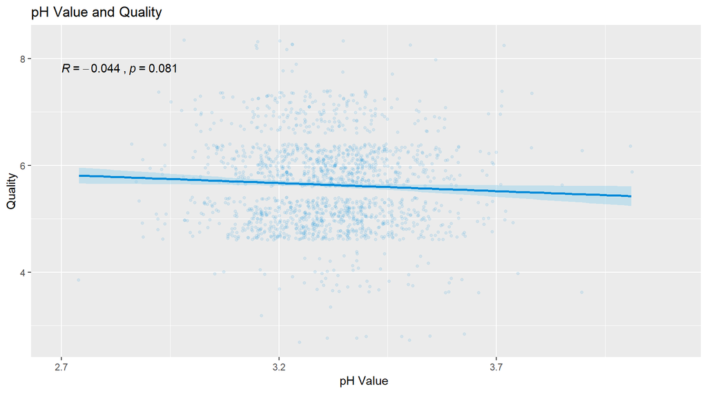

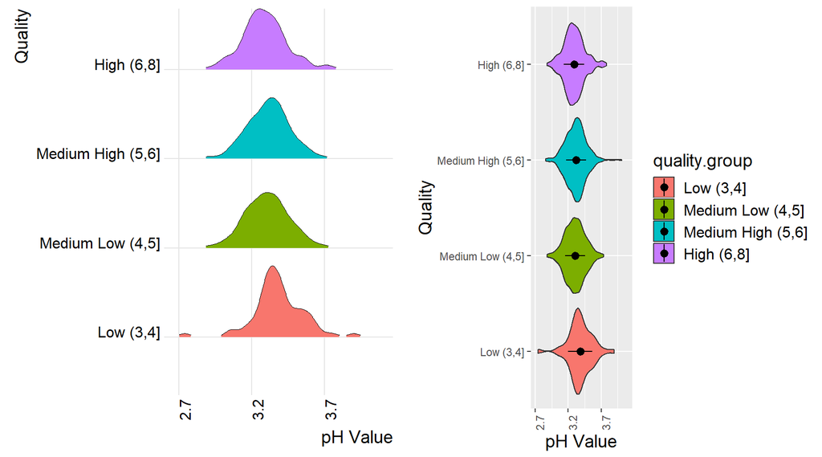

PH values and Quality

From scatter plot, it can be seen that the quality score does not have any changes, when pH increase.

In the ridgeline and violine plot, the x of the distributions does not move, with the change of the quality groups. The shape of the 4 groups in the plots are very similar.

Thus, I guess pH and Quality are not correlated.

The spearman coefficient is -0.044 (not correlated), indicating a same result as what we got from the plots.

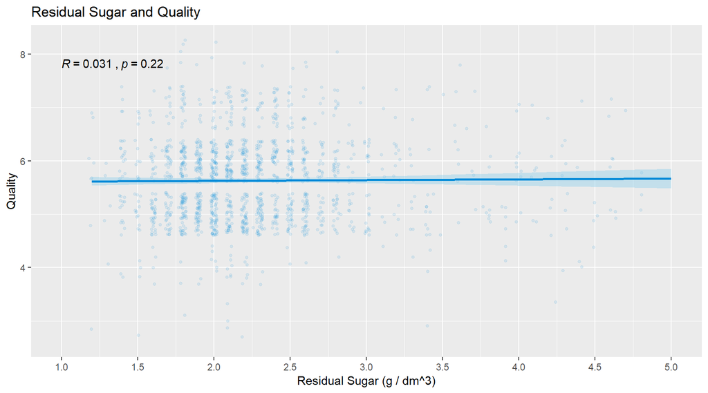

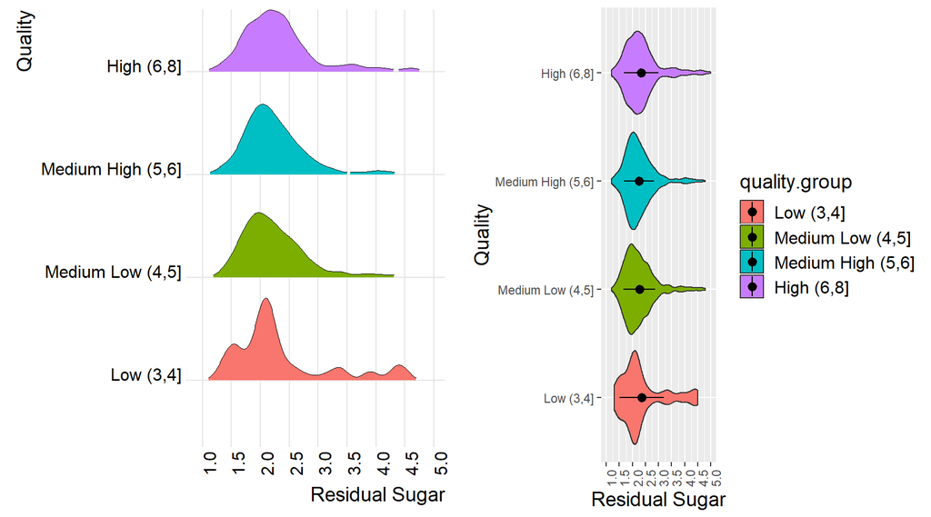

Residual Sugar and Quality

From scatter plot, it can be seen that the quality score does not have any changes, when Residual Sugar increase.

In the ridgeline and violine plot, the x of the distributions does not move, with the change of the quality groups. The shape of the 3 groups at the top are very similar.

Thus, I guess Residual Sugar and Quality are not correlated.

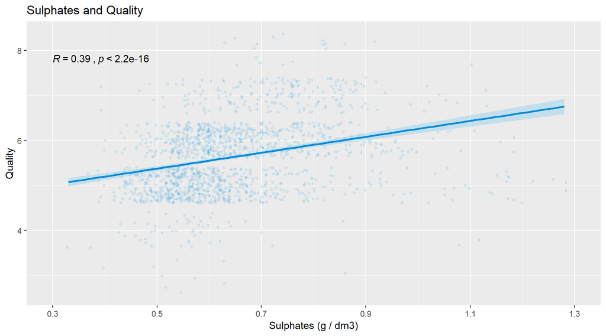

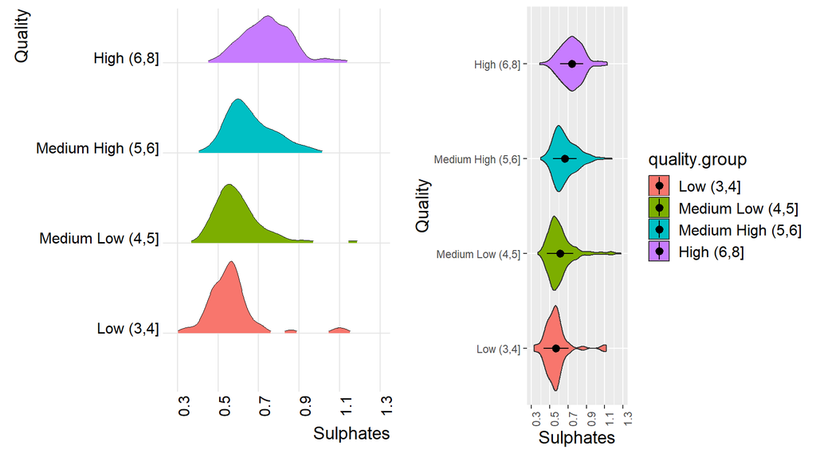

Sulphates and Quality

From the ridgeline and violine plot, it could be found that when the quality score increases, the Sulphates distribution moves to the right (Sulphates increase). Besides, the shapes are similar to each other.

Thus, I guess even though they are positively correlated, the correlation might not be strong.

The spearman coefficient (0.39) shows that they are mild correlated.